# Informe

Inigo Martiarena Conde

11/30/2020

## Estimar el modelo garch de BMW

El modelo GARCH es un modelo autorregresivo generalizado que captura las agrupaciones de volatilidad de las rentabilidades a través de la varianza condicional

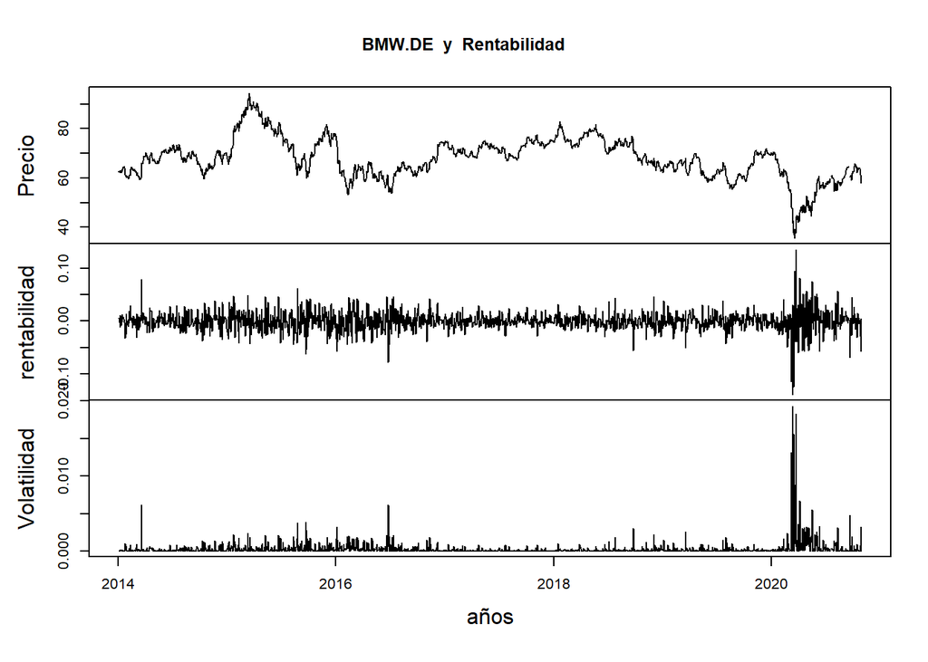

```
##
##  One Sample t-test
##
## data:  dRentCont
## t = -0.093641, df = 1727, p-value = 0.9254
## alternative hypothesis: true mean is not equal to 0
## 95 percent confidence interval:
##  -0.0008713763  0.0007919625
## sample estimates:
##     mean of x
## -3.970692e-05
```

Procedemos a calcular la autocorrelación y la correlación parcial:

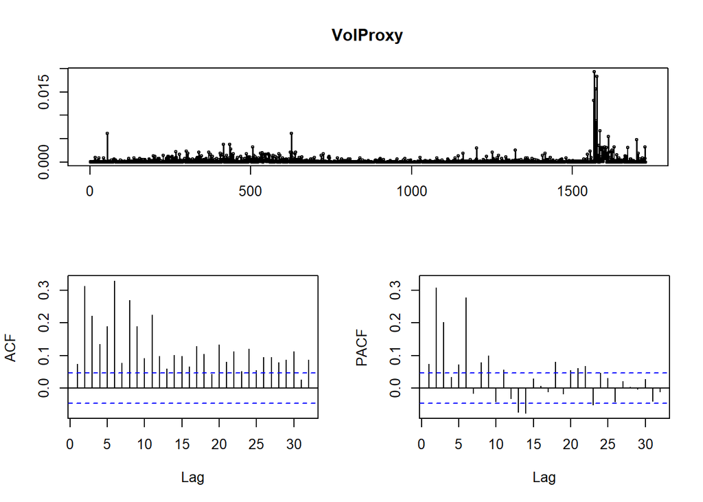

La prueba jung-Box es un tipo de prueba estadística de si un grupo cualquiera de autocorrelaciones de una serie temporal diferentes de cero.

En lugar de probar la aleatoriedad en cada retardo distinto, esta prueba la aleatoriedad “en general” basado en un número de retardos.

La autocorrelación reduce la exactitud de un modelo predictivo basado en el tiempo y conducir a una interpretación errónea de los datos.

```
##
##  Box-Ljung test
##
## data:  VolProxy
## X-squared = 759.15, df = 10, p-value < 2.2e-16
```

```
##
##  Box-Ljung test
##
## data:  VolProxy
## X-squared = 995.21, df = 20, p-value < 2.2e-16
```

```
##
##  Box-Ljung test
##
## data:  VolProxy
## X-squared = 1232, df = 40, p-value < 2.2e-16
```

```
##
## Call:
## lm(formula = atsq ~ x)
##
## Residuals:
##        Min         1Q     Median         3Q        Max
## -0.0048162 -0.0002192 -0.0001060  0.0000509  0.0180403
##
## Coefficients:
##               Estimate Std. Error t value Pr(>|t|)
## (Intercept)  8.936e-05  2.560e-05   3.491 0.000494 ***
## x1          -3.760e-02  2.431e-02  -1.547 0.122160
## x2           2.421e-01  2.441e-02   9.917  < 2e-16 ***
## x3           9.614e-02  2.507e-02   3.835 0.000130 ***
## x4          -1.998e-02  2.518e-02  -0.794 0.427562
## x5           8.088e-02  2.518e-02   3.213 0.001341 **
## x6           2.548e-01  2.525e-02  10.093  < 2e-16 ***
## x7          -1.905e-02  2.591e-02  -0.735 0.462307
## x8           1.157e-01  2.584e-02   4.476  8.1e-06 ***
## x9           7.267e-02  2.597e-02   2.798 0.005197 **
## x10         -3.542e-02  2.595e-02  -1.365 0.172522
## x11          8.256e-02  2.595e-02   3.181 0.001495 **
## x12         -4.497e-02  2.597e-02  -1.731 0.083582 .
## x13         -8.715e-02  2.585e-02  -3.372 0.000764 ***
## x14         -8.747e-02  2.593e-02  -3.373 0.000760 ***
## x15          1.946e-02  2.526e-02   0.770 0.441229
## x16         -1.142e-02  2.518e-02  -0.454 0.650168
## x17         -1.002e-02  2.518e-02  -0.398 0.690824
## x18          6.738e-02  2.507e-02   2.687 0.007271 **
## x19         -1.458e-02  2.442e-02  -0.597 0.550582
## x20          5.415e-02  2.440e-02   2.219 0.026617 *
## ---
## Signif. codes:  0 '***' 0.001 '**' 0.01 '*' 0.05 '.' 0.1 ' ' 1
##
## Residual standard error: 0.0008726 on 1687 degrees of freedom
## Multiple R-squared:  0.2446, Adjusted R-squared:  0.2356
## F-statistic: 27.31 on 20 and 1687 DF,  p-value: < 2.2e-16
```

```
##
## Title:
##  GARCH Modelling
##
## Call:
##  garchFit(formula = ~1 + garch(1, 0), data = dRentCont, trace = F)
##
## Mean and Variance Equation:
##  data ~ 1 + garch(1, 0)
## <environment: 0x000000001db56908>
##  [data = dRentCont]
##
## Conditional Distribution:
##  norm
##
## Coefficient(s):
##         mu       omega      alpha1
## 2.1908e-05  2.2793e-04  3.1802e-01
##
## Std. Errors:
##  based on Hessian
##
## Error Analysis:
##         Estimate  Std. Error  t value Pr(>|t|)
## mu     2.191e-05   3.911e-04    0.056    0.955
## omega  2.279e-04   1.030e-05   22.126  < 2e-16 ***
## alpha1 3.180e-01   4.541e-02    7.004 2.49e-12 ***
## ---
## Signif. codes:  0 '***' 0.001 '**' 0.01 '*' 0.05 '.' 0.1 ' ' 1
##
## Log Likelihood:
##  4581.306    normalized:  2.651219
##
## Description:
##  Mon Nov 30 22:43:32 2020 by user: inigo
##
##
## Standardised Residuals Tests:
##                                 Statistic p-Value
##  Jarque-Bera Test   R    Chi^2  3868.766  0
##  Shapiro-Wilk Test  R    W      0.9369562 0
##  Ljung-Box Test     R    Q(10)  20.96566  0.0213343
##  Ljung-Box Test     R    Q(15)  28.91217  0.01650863
##  Ljung-Box Test     R    Q(20)  33.98949  0.02619589
##  Ljung-Box Test     R^2  Q(10)  316.948   0
##  Ljung-Box Test     R^2  Q(15)  380.9459  0
##  Ljung-Box Test     R^2  Q(20)  473.9984  0
##  LM Arch Test       R    TR^2   231.5013  0
##
## Information Criterion Statistics:
##       AIC       BIC       SIC      HQIC
## -5.298965 -5.289495 -5.298971 -5.295462
```

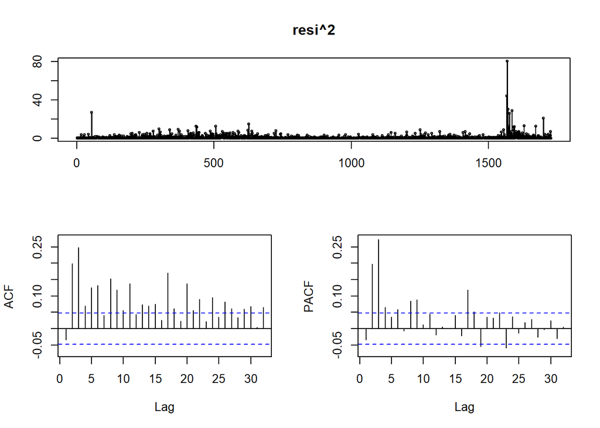

# GARCH(1,1)

```
##
## Title:
##  GARCH Modelling
##
## Call:
##  garchFit(formula = ~1 + garch(1, 1), data = dRentCont, trace = F)
##
## Mean and Variance Equation:
##  data ~ 1 + garch(1, 1)
## <environment: 0x000000001f4c9720>
##  [data = dRentCont]
##
## Conditional Distribution:
##  norm
##
## Coefficient(s):
##         mu       omega      alpha1       beta1
## 2.4480e-04  2.5322e-06  4.9566e-02  9.4275e-01
##
## Std. Errors:
##  based on Hessian
##
## Error Analysis:
##         Estimate  Std. Error  t value Pr(>|t|)
## mu     2.448e-04   3.368e-04    0.727  0.46728
## omega  2.532e-06   9.759e-07    2.595  0.00947 **
## alpha1 4.957e-02   7.941e-03    6.242 4.32e-10 ***
## beta1  9.427e-01   9.457e-03   99.689  < 2e-16 ***
## ---
## Signif. codes:  0 '***' 0.001 '**' 0.01 '*' 0.05 '.' 0.1 ' ' 1
##
## Log Likelihood:
##  4751.161    normalized:  2.749514
##
## Description:
##  Mon Nov 30 22:43:32 2020 by user: inigo
##
##
## Standardised Residuals Tests:
##                                 Statistic p-Value
##  Jarque-Bera Test   R    Chi^2  763.5816  0
##  Shapiro-Wilk Test  R    W      0.9719484 0
##  Ljung-Box Test     R    Q(10)  21.22249  0.01959442
##  Ljung-Box Test     R    Q(15)  25.44835  0.04423666
##  Ljung-Box Test     R    Q(20)  31.26611  0.05177399
##  Ljung-Box Test     R^2  Q(10)  22.55164  0.01252817
##  Ljung-Box Test     R^2  Q(15)  23.89845  0.06683815
##  Ljung-Box Test     R^2  Q(20)  27.35404  0.125594
##  LM Arch Test       R    TR^2   23.40251  0.02449674
##
## Information Criterion Statistics:
##       AIC       BIC       SIC      HQIC
## -5.494399 -5.481772 -5.494410 -5.489728
```

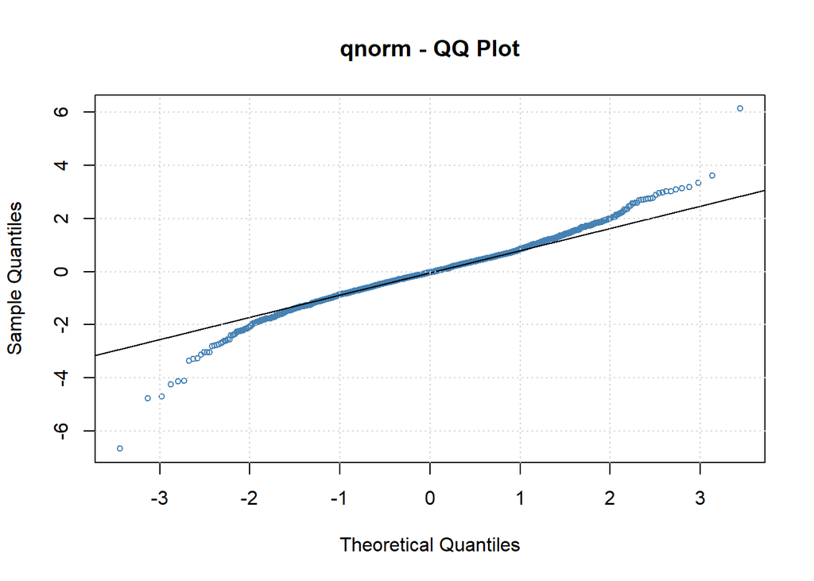

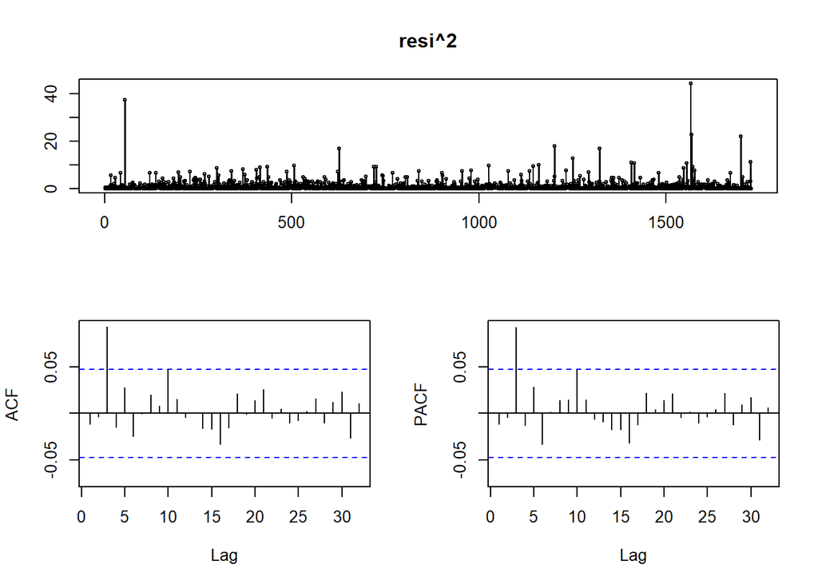

```
##
## Title:
##  GARCH Modelling
##
## Call:
##  garchFit(formula = ~1 + garch(1, 1), data = dRentCont, cond.dist = "std",
##     trace = F)
##
## Mean and Variance Equation:
##  data ~ 1 + garch(1, 1)
## <environment: 0x0000000015854f90>
##  [data = dRentCont]
##
## Conditional Distribution:
##  std
##
## Coefficient(s):
##          mu        omega       alpha1        beta1        shape
## -4.1960e-05   2.0572e-06   4.6600e-02   9.4830e-01   4.9763e+00
##
## Std. Errors:
##  based on Hessian
##
## Error Analysis:
##          Estimate  Std. Error  t value Pr(>|t|)
## mu     -4.196e-05   3.090e-04   -0.136   0.8920
## omega   2.057e-06   9.588e-07    2.146   0.0319 *
## alpha1  4.660e-02   9.794e-03    4.758 1.96e-06 ***
## beta1   9.483e-01   1.033e-02   91.845  < 2e-16 ***
## shape   4.976e+00   6.083e-01    8.181 2.22e-16 ***
## ---
## Signif. codes:  0 '***' 0.001 '**' 0.01 '*' 0.05 '.' 0.1 ' ' 1
##
## Log Likelihood:
##  4822.855    normalized:  2.791004
##
## Description:
##  Mon Nov 30 22:43:33 2020 by user: inigo
##
##
## Standardised Residuals Tests:
##                                 Statistic p-Value
##  Jarque-Bera Test   R    Chi^2  794.1946  0
##  Shapiro-Wilk Test  R    W      0.9715777 0
##  Ljung-Box Test     R    Q(10)  21.42503  0.0183172
##  Ljung-Box Test     R    Q(15)  25.58087  0.04266584
##  Ljung-Box Test     R    Q(20)  31.41152  0.04998681
##  Ljung-Box Test     R^2  Q(10)  26.11435  0.0035894
##  Ljung-Box Test     R^2  Q(15)  27.45445  0.0252445
##  Ljung-Box Test     R^2  Q(20)  31.10622  0.05380372
##  LM Arch Test       R    TR^2   27.00332  0.007718694
##
## Information Criterion Statistics:
##       AIC       BIC       SIC      HQIC
## -5.576221 -5.560437 -5.576237 -5.570382
```

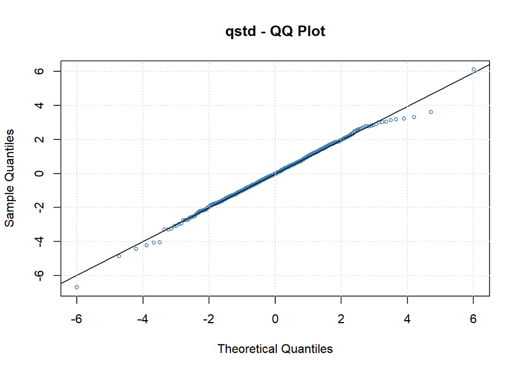

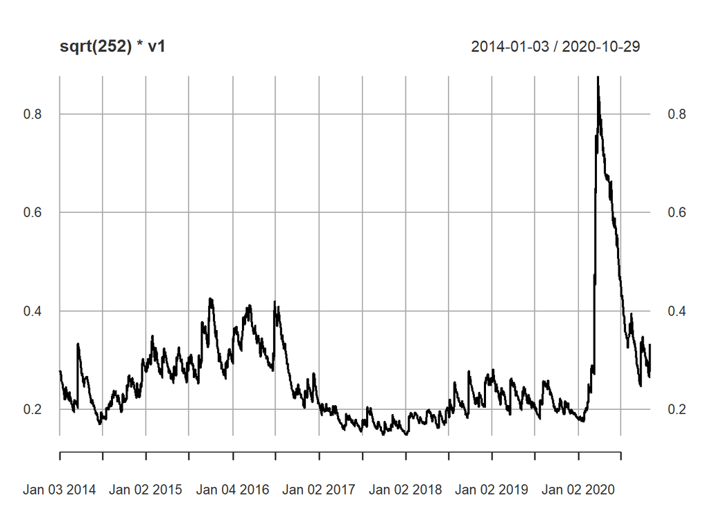

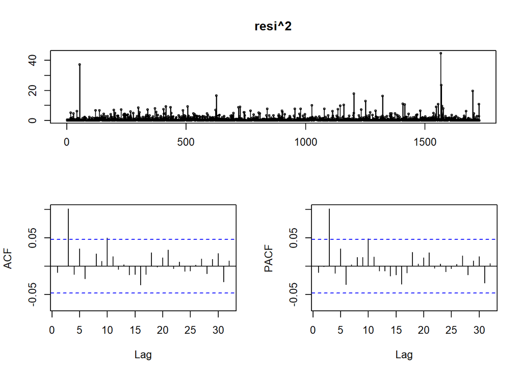

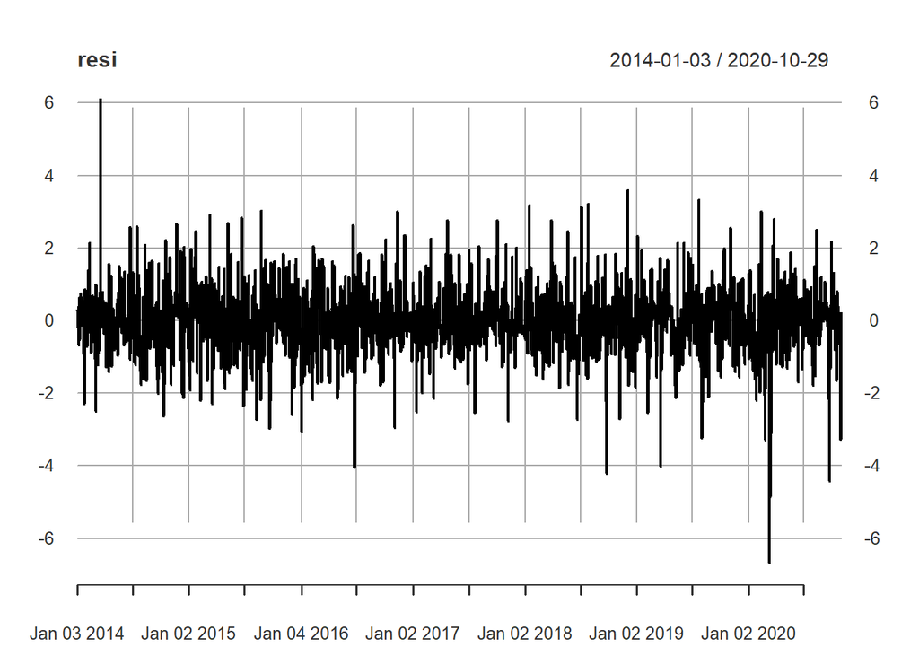

Por último vamos a realizar la predicción de la volatilidad de nuestra serie:

```
##     meanForecast  meanError standardDeviation
## 1  -4.196021e-05 0.02052098        0.02052098
## 2  -4.196021e-05 0.02051881        0.02051881
## 3  -4.196021e-05 0.02051666        0.02051666
## 4  -4.196021e-05 0.02051452        0.02051452
## 5  -4.196021e-05 0.02051239        0.02051239
## 6  -4.196021e-05 0.02051028        0.02051028
## 7  -4.196021e-05 0.02050817        0.02050817
## 8  -4.196021e-05 0.02050607        0.02050607
## 9  -4.196021e-05 0.02050398        0.02050398
## 10 -4.196021e-05 0.02050190        0.02050190
```

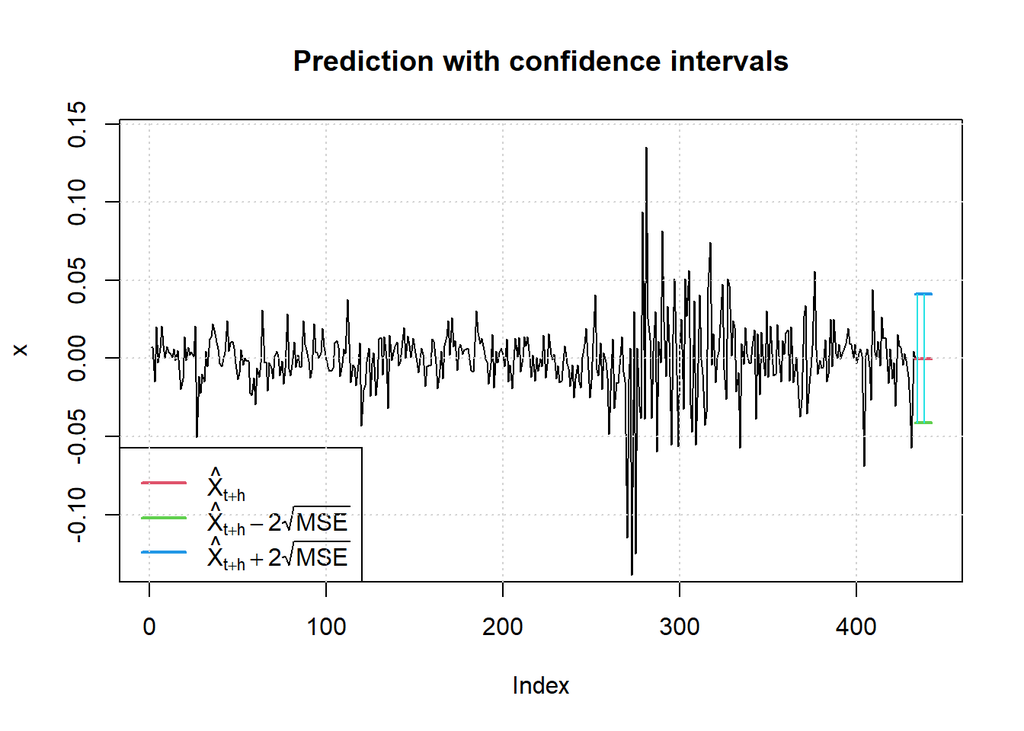

```
##     meanForecast  meanError standardDeviation lowerInterval upperInterval
## 1  -4.196021e-05 0.02052098        0.02052098   -0.04108391    0.04099999
## 2  -4.196021e-05 0.02051881        0.02051881   -0.04107959    0.04099567
## 3  -4.196021e-05 0.02051666        0.02051666   -0.04107529    0.04099137
## 4  -4.196021e-05 0.02051452        0.02051452   -0.04107101    0.04098709
## 5  -4.196021e-05 0.02051239        0.02051239   -0.04106675    0.04098283
## 6  -4.196021e-05 0.02051028        0.02051028   -0.04106251    0.04097859
## 7  -4.196021e-05 0.02050817        0.02050817   -0.04105829    0.04097437
## 8  -4.196021e-05 0.02050607        0.02050607   -0.04105410    0.04097018
## 9  -4.196021e-05 0.02050398        0.02050398   -0.04104992    0.04096600
## 10 -4.196021e-05 0.02050190        0.02050190   -0.04104577    0.04096185
```

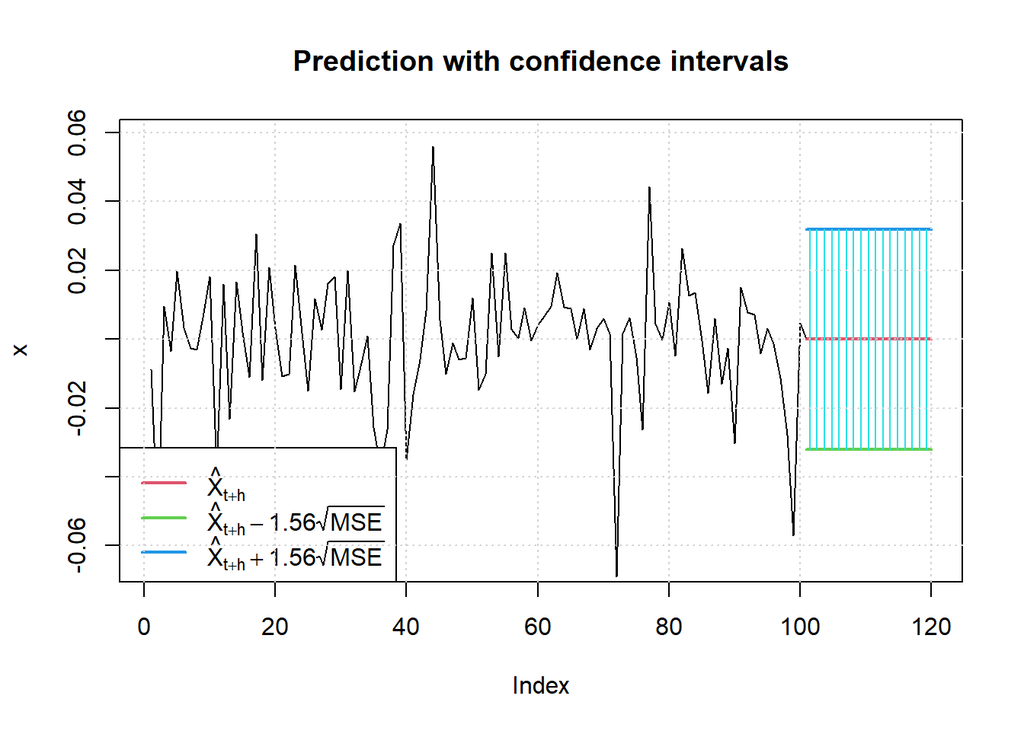

```
##     meanForecast  meanError standardDeviation lowerInterval upperInterval
## 1  -4.196021e-05 0.02052098        0.02052098   -0.03205488    0.03197096
## 2  -4.196021e-05 0.02051881        0.02051881   -0.03205151    0.03196759
## 3  -4.196021e-05 0.02051666        0.02051666   -0.03204816    0.03196423
## 4  -4.196021e-05 0.02051452        0.02051452   -0.03204482    0.03196090
## 5  -4.196021e-05 0.02051239        0.02051239   -0.03204149    0.03195757
## 6  -4.196021e-05 0.02051028        0.02051028   -0.03203819    0.03195427
## 7  -4.196021e-05 0.02050817        0.02050817   -0.03203490    0.03195098
## 8  -4.196021e-05 0.02050607        0.02050607   -0.03203163    0.03194771
## 9  -4.196021e-05 0.02050398        0.02050398   -0.03202837    0.03194445
## 10 -4.196021e-05 0.02050190        0.02050190   -0.03202513    0.03194121
## 11 -4.196021e-05 0.02049984        0.02049984   -0.03202191    0.03193799
## 12 -4.196021e-05 0.02049778        0.02049778   -0.03201870    0.03193478
## 13 -4.196021e-05 0.02049574        0.02049574   -0.03201551    0.03193159
## 14 -4.196021e-05 0.02049370        0.02049370   -0.03201233    0.03192841
## 15 -4.196021e-05 0.02049168        0.02049168   -0.03200917    0.03192525
## 16 -4.196021e-05 0.02048966        0.02048966   -0.03200603    0.03192211
## 17 -4.196021e-05 0.02048765        0.02048765   -0.03200290    0.03191898
## 18 -4.196021e-05 0.02048566        0.02048566   -0.03199979    0.03191587
## 19 -4.196021e-05 0.02048367        0.02048367   -0.03199669    0.03191277
## 20 -4.196021e-05 0.02048170        0.02048170   -0.03199361    0.03190969
```

## Modelo VAR.

Entre sus ventajas podemos destacar que es fácil de estimar, sus variables pueden ser no ser estacionarias y los errores pueden ser corregidos en el momento.

Para está practica, vamos a trabajar con los “daily adjusted closing prices”

Lo primero que hemos hecho es excluir los NA de nuestra serie BMW y de Volkswagen con el objetivo de obtener un modelo más preciso. Luego le hemos quitado la constante porque el valor de los estimadores y el r^2 son muy pequeños.

```
## $selection
## AIC(n)  HQ(n)  SC(n) FPE(n)
##      2      1      1      2
##
## $criteria
##                    1             2             3             4             5
## AIC(n) -9.873837e+00 -9.888421e+00 -9.855114e+00 -9.819385e+00 -9.816003e+00
## HQ(n)  -9.826400e+00 -9.809361e+00 -9.744430e+00 -9.677076e+00 -9.642070e+00
## SC(n)  -9.757037e+00 -9.693756e+00 -9.582583e+00 -9.468987e+00 -9.387739e+00
## FPE(n)  5.150523e-05  5.076121e-05  5.248432e-05  5.440071e-05  5.459637e-05
##                    6             7             8             9            10
## AIC(n) -9.784725e+00 -9.784453e+00 -9.743679e+00 -9.730028e+00 -9.781853e+00
## HQ(n)  -9.579167e+00 -9.547271e+00 -9.474873e+00 -9.429598e+00 -9.449799e+00
## SC(n)  -9.278595e+00 -9.200457e+00 -9.081816e+00 -8.990300e+00 -8.964258e+00
## FPE(n)  5.634796e-05  5.638636e-05  5.876443e-05  5.961259e-05  5.664951e-05
```

```
##
## VAR Estimation Results:
## =========================
## Endogenous variables: BMW, VW
## Deterministic variables: const
## Sample size: 166
## Log Likelihood: 344.492
## Roots of the characteristic polynomial:
## 0.1616 0.1616
## Call:
## VAR(y = vY)
##
##
## Estimation results for equation BMW:
## ====================================
## BMW = BMW.l1 + VW.l1 + const
##
##         Estimate Std. Error t value Pr(>|t|)
## BMW.l1  0.063784   0.102741   0.621    0.536
## VW.l1  -0.109665   0.075534  -1.452    0.148
## const   0.010420   0.006738   1.547    0.124
##
##
## Residual standard error: 0.08613 on 163 degrees of freedom
## Multiple R-Squared: 0.01368, Adjusted R-squared: 0.001577
## F-statistic:  1.13 on 2 and 163 DF,  p-value: 0.3254
##
##
## Estimation results for equation VW:
## ===================================
## VW = BMW.l1 + VW.l1 + const
##
##        Estimate Std. Error t value Pr(>|t|)
## BMW.l1  0.29944    0.13663   2.192   0.0298 *
## VW.l1  -0.10529    0.10045  -1.048   0.2961
## const   0.01383    0.00896   1.543   0.1247
## ---
## Signif. codes:  0 '***' 0.001 '**' 0.01 '*' 0.05 '.' 0.1 ' ' 1
##
##
## Residual standard error: 0.1145 on 163 degrees of freedom
## Multiple R-Squared: 0.02978, Adjusted R-squared: 0.01787
## F-statistic: 2.501 on 2 and 163 DF,  p-value: 0.08513
##
##
##
## Covariance matrix of residuals:
##          BMW       VW
## BMW 0.007418 0.006425
## VW  0.006425 0.013118
##
## Correlation matrix of residuals:
##        BMW     VW
## BMW 1.0000 0.6514
## VW  0.6514 1.0000
```

```
##
## VAR Estimation Results:
## =========================
## Endogenous variables: BMW, VW
## Deterministic variables: none
## Sample size: 166
## Log Likelihood: 343.033
## Roots of the characteristic polynomial:
## 0.1564 0.1564
## Call:
## VAR(y = vY, type = "none")
##
##
## Estimation results for equation BMW:
## ====================================
## BMW = BMW.l1 + VW.l1
##
##        Estimate Std. Error t value Pr(>|t|)
## BMW.l1  0.06870    0.10313   0.666    0.506
## VW.l1  -0.10102    0.07565  -1.335    0.184
##
##
## Residual standard error: 0.08649 on 164 degrees of freedom
## Multiple R-Squared: 0.01112, Adjusted R-squared: -0.0009436
## F-statistic: 0.9218 on 2 and 164 DF,  p-value: 0.3999
##
##
## Estimation results for equation VW:
## ===================================
## VW = BMW.l1 + VW.l1
##
##        Estimate Std. Error t value Pr(>|t|)
## BMW.l1  0.30596    0.13714   2.231    0.027 *
## VW.l1  -0.09382    0.10059  -0.933    0.352
## ---
## Signif. codes:  0 '***' 0.001 '**' 0.01 '*' 0.05 '.' 0.1 ' ' 1
##
##
## Residual standard error: 0.115 on 164 degrees of freedom
## Multiple R-Squared: 0.03183, Adjusted R-squared: 0.02002
## F-statistic: 2.696 on 2 and 164 DF,  p-value: 0.07047
##
##
##
## Covariance matrix of residuals:
##          BMW       VW
## BMW 0.007374 0.006388
## VW  0.006388 0.013041
##
## Correlation matrix of residuals:
##        BMW     VW
## BMW 1.0000 0.6514
## VW  0.6514 1.0000
```

```
## $Granger
##
##  Granger causality H0: BMW do not Granger-cause VW
##
## data:  VAR object model.var1
## F-Test = 4.9775, df1 = 1, df2 = 328, p-value = 0.02636
##
##
## $Instant
##
##  H0: No instantaneous causality between: BMW and VW
##
## data:  VAR object model.var1
## Chi-squared = 49.984, df = 1, p-value = 1.55e-12
```

Con la representacion del siguiente impulso, vemos el efecto que tiene la variablididad de BWM en Volkswagen y viceversa.

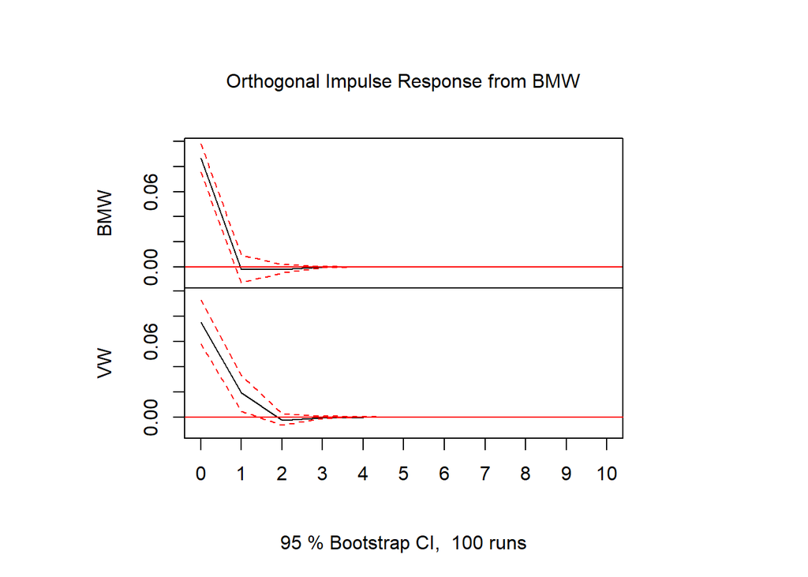

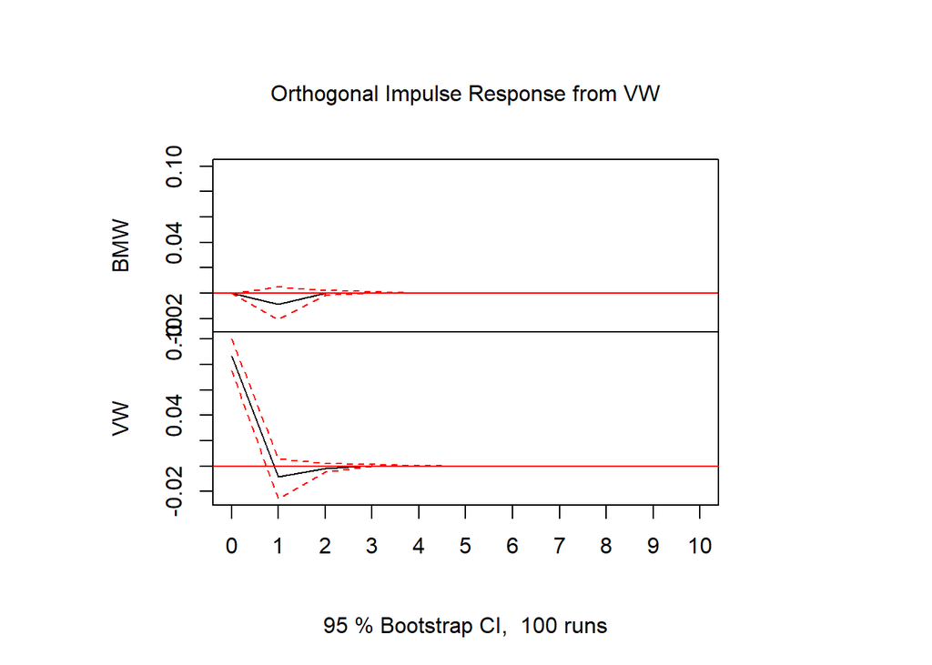

Hacemos un prediccion de para los proximos 8 periodos para ambas series con un intervalo de confianza del 95%:

```
## $BMW
##               fcst      lower     upper        CI
## [1,]  5.655493e-05 -0.1694615 0.1695746 0.1695180
## [2,] -6.008855e-03 -0.1764273 0.1644095 0.1704184
## [3,]  1.496040e-04 -0.1703178 0.1706170 0.1704674
## [4,]  1.432373e-04 -0.1703248 0.1706112 0.1704680
## [5,] -7.259004e-06 -0.1704753 0.1704608 0.1704680
## [6,] -3.321659e-06 -0.1704713 0.1704647 0.1704680
## [7,]  2.610443e-07 -0.1704678 0.1704683 0.1704680
## [8,]  7.469939e-08 -0.1704679 0.1704681 0.1704680
##
## $VW
##               fcst      lower     upper        CI
## [1,]  5.951869e-02 -0.1659047 0.2849421 0.2254234
## [2,] -5.566908e-03 -0.2347240 0.2235902 0.2291571
## [3,] -1.316142e-03 -0.2305497 0.2279175 0.2292336
## [4,]  1.692564e-04 -0.2290663 0.2294048 0.2292356
## [5,]  2.794420e-05 -0.2292077 0.2292636 0.2292356
## [6,] -4.842739e-06 -0.2292405 0.2292308 0.2292356
## [7,] -5.619218e-07 -0.2292362 0.2292350 0.2292356
## [8,]  1.325891e-07 -0.2292355 0.2292357 0.2292356
```